# 08 Recall and Accuracy

Rex W. Douglass and Kristen Harkness

12/9/2017

Demonstrates that georeferencing options vary terms of recall (how many event locations they recover) and accuracy (how far away their imputed locations tend to be from the true location)

```r
rm(list=ls()); gc()
# !diagnostics off
library(MeasuringLandscapeCivilWar)
devtools::load_all()
dir_figures <- glue(getwd(), "/../paper/figures/")
gc()
knitr::opts_knit$set(progress = TRUE, verbose = TRUE)
knitr::opts_chunk$set(fig.width=12, fig.height=8,  warning=FALSE, message=FALSE, cache=TRUE)
options(width = 160)
```

# Load Files

Load the events file

```r
#Load Events
events_sf <- readRDS(system.file("extdata", "events_sf.Rdata", package = "MeasuringLandscapeCivilWar"))
print(dim(events_sf))
```

```
[1] 10469   104
```

```r
events_sf_text_coord_unique <- ddply(events_sf[,c('location_text','name_clean','name_cleaner','document_district_clean','map_coordinate_clean_latitude','map_coordinate_clean_longitude')],
                                     .(location_text), transform,
      map_coordinate_has =sum(!is.na(map_coordinate_clean_latitude))
      )
```

Load the suggestions file

```r
#Reload from scratch each time in case we subset sometehing weirdly
georef_all_dt <- readRDS(system.file("extdata", "georef_all_dt.Rds", package = "MeasuringLandscapeCivilWar"))
glue("Size of the Suggestions dataset ", nrow(georef_all_dt))
```

```
Size of the Suggestions dataset 539268
```

```r
table(!is.na(events_sf$name_cleaner)) #8,638 events have at least some text
```

```
FALSE  TRUE
 1831  8638
```

```r
table(events_sf$name_cleaner %in% georef_all_dt$name_cleaner) #8,242 events have a name in our suggestions list
```

```
 TRUE
10469
```

```r
table(events_sf$name_cleaner %in% georef_all_dt$name_cleaner[!is.na(georef_all_dt$georef_b)]) #7,532 events with at least one gazeteer suggestion
```

```
FALSE  TRUE
 2541  7928
```

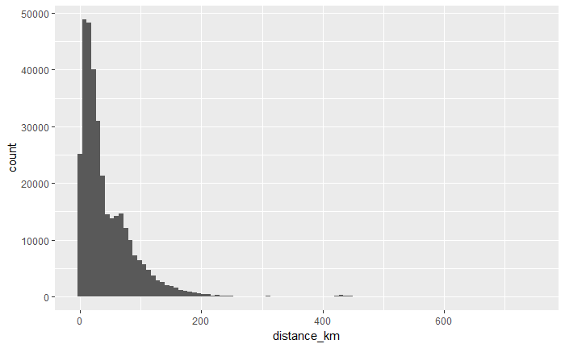

```r
georef_all_dt %>% ggplot(aes(x=distance_km)) + geom_histogram(bins = 100)
```

```r
georef_all_dt %>% summary(distance_km)
```

```
  event_hash        name_cleaner       document_district_clean document_unit_type document_date_best_year   georef_b
 Length:539268      Length:539268      Length:539268           Length:539268      Min.   :1952            Length:539268
 Class :character   Class :character   Class :character        Class :character   1st Qu.:1953            Class :character
 Mode  :character   Mode  :character   Mode  :character        Mode  :character   Median :1954            Mode  :character
                                                                                  Mean   :1954
                                                                                  3rd Qu.:1954
                                                                                  Max.   :2052
                                                                                  NA's   :63560
 toponym_xb_model_prediction  place_hash        source_dataset     geometry_type      feature_code             X1               Y1
 Min.   :0.5000              Length:539268      Length:539268      Length:539268      Length:539268      Min.   :34.88    Min.   :-2.70
 1st Qu.:0.9648              Class :character   Class :character   Class :character   Class :character   1st Qu.:36.85    1st Qu.:-0.84
 Median :0.9965              Mode  :character   Mode  :character   Mode  :character   Mode  :character   Median :36.99    Median :-0.65
 Mean   :0.9352                                                                                          Mean   :37.05    Mean   :-0.65
 3rd Qu.:0.9965                                                                                          3rd Qu.:37.21    3rd Qu.:-0.45
 Max.   :0.9977                                                                                          Max.   :41.72    Max.   : 3.86
 NA's   :2541                                                                                            NA's   :198169   NA's   :198169
       X2              Y2           distance_km     SelfReference     fuzzy           handrule1       handrule2       handrule3
 Min.   :27.27   Min.   :-4.6667   Min.   :  0.00   Mode :logical   Mode :logical   Min.   :1.000   Min.   :1.000   Min.   :1.00
 1st Qu.:36.82   1st Qu.:-0.9438   1st Qu.: 13.00   FALSE:282936    FALSE:167425    1st Qu.:1.000   1st Qu.:1.000   1st Qu.:1.00
 Median :36.97   Median :-0.6732   Median : 28.16   TRUE :253791    TRUE :369302    Median :2.000   Median :2.000   Median :1.00
 Mean   :37.01   Mean   :-0.6815   Mean   : 44.27   NA's :2541      NA's :2541      Mean   :1.688   Mean   :1.527   Mean   :1.08
 3rd Qu.:37.19   3rd Qu.:-0.4597   3rd Qu.: 63.15                                   3rd Qu.:2.000   3rd Qu.:2.000   3rd Qu.:1.00
 Max.   :41.52   Max.   : 4.0616   Max.   :747.43                                   Max.   :2.000   Max.   :2.000   Max.   :4.00
 NA's   :2541    NA's   :2541      NA's   :198913                                   NA's   :2541    NA's   :2541    NA's   :2541
   handrule4        handrule         rule_ensemble
 Min.   : 1.000   Length:539268      Min.   :  0.3383
 1st Qu.: 1.000   Class :character   1st Qu.: 15.1581
 Median : 2.000   Mode  :character   Median : 21.8254
 Mean   : 3.221                      Mean   : 32.4840
 3rd Qu.: 4.000                      3rd Qu.: 44.6420
 Max.   :15.000                      Max.   :309.7039
 NA's   :2541
```

```r
table(georef_all_dt$distance_km==0) #These are identical matches, same event on the left hand and right hand sides
```

```
 FALSE   TRUE
335247   5108
```

```r
#Exclude all distance = 0 obs, those are self matches
georef_all_dt <- subset(georef_all_dt,
                        !is.na(name_cleaner) & # must have a name
                        (is.na(distance_km) | distance_km!=0)  ) #Can be either missing or not zero. Only thing we drop is zero because that's a self match
table(georef_all_dt$distance_km==0) #These are identical matches, same event on the left hand and right hand sides
```

```
 FALSE
335247
```

# Calculate Recall Rate and Distance for Ensembles

This section calculates the recall rate and geographic accuracy of gazeteer suggestions. Recall is the number of events that receive at least one suggestion under a given set of rules. Accuracy is the distance between an observed location with a military coordinate and an imputed location for the same event.

Accuracy is measured differently for hand rule/ensemble and every other specific decision. Hand rule/ensemble accuracy is the distance observed for the best match selected by that process.

Accuracy for the remainder of decisions is the BEST CASE accuracy for any suggestion matching that rule. For example, if the decision is “point” geometry type, then accuracy would be the smallest observed distance of every single suggestion with a point type.

Hand Rules

```r
print("Hand Rule Orderings")
```

```
[1] "Hand Rule Orderings"
```

```r
table(georef_all_dt$handrule)
```

```
01_01_01_01 01_02_01_02 01_02_01_03 01_02_01_04 01_02_01_06 01_02_01_07 01_02_01_09 01_02_01_10 01_02_01_13 01_02_01_14 01_02_02_05 01_02_02_11
     116885        7253        7301        7772        6175        3063        1641        1320        2326        1846        3354         816
01_02_02_12 01_02_02_14 01_02_03_08 01_02_03_15 01_02_04_14 02_01_01_01 02_02_01_02 02_02_01_03 02_02_01_04 02_02_01_06 02_02_01_07 02_02_01_09
        587          70        2075          22         169      131798       43952       51286       54761       30986        6530       10185
02_02_01_10 02_02_01_13 02_02_01_14 02_02_02_05 02_02_02_11 02_02_02_12 02_02_02_14 02_02_02_15 02_02_03_08 02_02_03_14 02_02_03_15 02_02_04_14
       1508        8652        9133        7565         219          90        1966         242        6855          74         147        2995
NA_NA_NA_NA
        710
```

```r
#Hand Rule
setkey(georef_all_dt, event_hash, handrule) #Sort by event and then hand rule
georef_all_dt_handrule <- georef_all_dt[,.SD[1], by=list(event_hash) ] #Take the smallest hand rule score, lower is better
georef_all_dt_handrule_summary <- georef_all_dt_handrule[,list(
                                               rule="Hand Rule",
                                              distance_rmse=sqrt(mean(distance_km^2, na.rm=T)),
                                              distance_mse=mean(distance_km^2, na.rm=T),
                                              distance_me=mean(distance_km, na.rm=T),
                                              distance_median=median(distance_km, na.rm=T),
                                              source_dataset_count=.N
                                              )
                                        ]
print("Distance for Hand Rule")
```

```
[1] "Distance for Hand Rule"
```

```r
georef_all_dt_handrule_summary
```

| rule | distance_rmse | distance_mse | distance_me | distance_median | source_dataset_count |
| --- | --- | --- | --- | --- | --- |
| Hand Rule | 54.6499 | 2986.611 | 31.10806 | 13.8518 | 8211 |

Ensemble Rule

```r
summary(georef_all_dt$rule_ensemble)
```

```
    Min.  1st Qu.   Median     Mean  3rd Qu.     Max.
  0.3383  15.4941  21.8254  32.7014  45.1486 309.7039
```

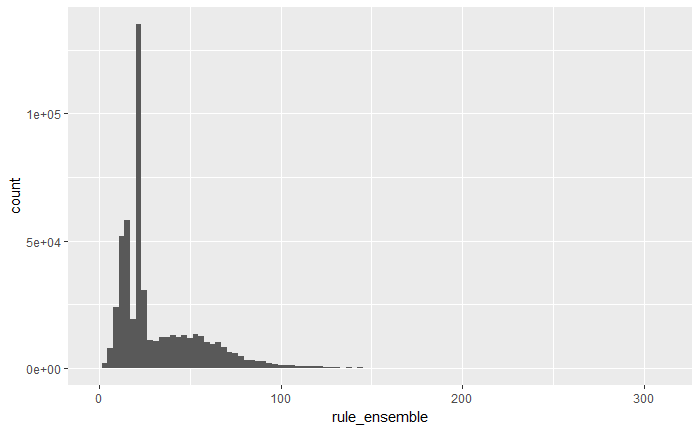

```r
georef_all_dt %>% ggplot(aes(x=rule_ensemble)) + geom_histogram(bins=100)
```

```r
#Ensemble Rule
setkey(georef_all_dt, rule_ensemble)
georef_all_dt_ensemble <- georef_all_dt[,.SD[1], by=list(event_hash) ] #Take the smallest estimated distance, lower is better
georef_all_dt_ensemble_summary <- georef_all_dt_ensemble[,list(
                                               rule="Ensemble Rule",
                                              distance_rmse=sqrt(mean(distance_km^2, na.rm=T)) ,
                                              distance_mse=mean(distance_km^2, na.rm=T),
                                              distance_me=mean(distance_km, na.rm=T),
                                              distance_median=median(distance_km, na.rm=T),
                                              source_dataset_count=.N
                                              )
                                        ]
print("Distance for Ensemble")
```

```
[1] "Distance for Ensemble"
```

```r
georef_all_dt_ensemble_summary
```

| rule | distance_rmse | distance_mse | distance_me | distance_median | source_dataset_count |
| --- | --- | --- | --- | --- | --- |
| Ensemble Rule | 53.15621 | 2825.583 | 30.45118 | 13.10322 | 8211 |

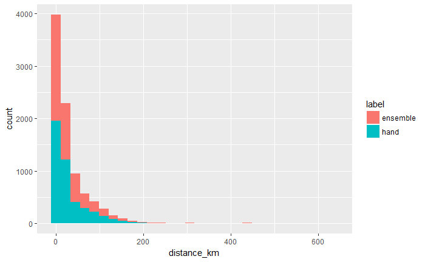

```r
rbind(georef_all_dt_handrule %>% mutate(label="hand"),
      georef_all_dt_ensemble %>% mutate(label="ensemble")) %>%
      ggplot(aes(x=distance_km, fill=label)) + geom_histogram()
```

```r
#Need to compare on just the intersection of the points they provide answers to?
```

# Calculate Recall Rate and Distance for Each Decision

Now calculate the minimum observed distance for any suggestion matching a specific decision.

```r
#Minimum distance by event-source
georef_all_dt_bysource <- georef_all_dt[,
                                        list(distance_min=min(distance_km, na.rm=T) ),
                                        by=list(event_hash, source_dataset)] ; dim(georef_all_dt_bysource)
```

```
No non-missing values found in at least one group. Returning 'Inf' for such groups to be consistent with base
```

```
[1] 58095     3
```

```r
georef_all_dt_bysource[!is.finite(distance_min), distance_min:=NA]
#Minimum distance and recall by source
georef_all_dt_bysource_summary <- georef_all_dt_bysource[,
                                                    list(
                                                      distance_rmse=sqrt(mean(distance_min^2, na.rm=T)) ,
                                                      source_dataset_count=.N),
                                                      by=list(source_dataset)
                                                ]
georef_all_dt_byfuzzy <- georef_all_dt[
                                      ,list(distance_min=min(distance_km, na.rm=T) ),
                                      by=list(event_hash, fuzzy)] ;
```

```
No non-missing values found in at least one group. Returning 'Inf' for such groups to be consistent with base
```

```r
georef_all_dt_byfuzzy[!is.finite(distance_min), distance_min:=NA]
georef_all_dt_byfuzzy_summary <- georef_all_dt_byfuzzy[,
                                                       list(distance_rmse=sqrt(mean(distance_min^2, na.rm=T)) ,
                                                      source_dataset_count=.N),
                                                      by=list(fuzzy) ]
georef_all_dt_byselfreference <- georef_all_dt[,list(distance_min=min(distance_km, na.rm=T) ),
                                               by=list(event_hash, SelfReference)] ; dim(georef_all_dt_bysource)
```

```
No non-missing values found in at least one group. Returning 'Inf' for such groups to be consistent with base
```

```
[1] 58095     3
```

```r
georef_all_dt_byselfreference[!is.finite(distance_min), distance_min:=NA]
georef_all_dt_byselfreference_summary <- georef_all_dt_byselfreference[,list(
                                                      distance_rmse=sqrt(mean(distance_min^2, na.rm=T)) ,
                                                      source_dataset_count=.N),
                                                      by=list(SelfReference)
                                                ]
georef_all_dt_bygeometry_type <- georef_all_dt[,list(distance_min=min(distance_km, na.rm=T) ),by=list(event_hash, geometry_type
                                                                                            )] ; dim(georef_all_dt_bysource)
```

```
No non-missing values found in at least one group. Returning 'Inf' for such groups to be consistent with base
```

```
[1] 58095     3
```

```r
georef_all_dt_bygeometry_type[!is.finite(distance_min), distance_min:=NA]
georef_all_dt_bygeometry_type <- georef_all_dt_bygeometry_type[,list(
                                                      distance_rmse=sqrt(mean(distance_min^2, na.rm=T)) ,
                                                      source_dataset_count=.N),
                                                      by=list(geometry_type)
                                                ]
georef_all_dt_milcoords_summary <- data.frame(rule="Mil. Coord",
                                              distance_rmse=0,
                                              source_dataset_count=sum(!is.na(events_sf$map_coordinate_clean_latitude))
)
```

# Summarize

```r
recall_accuracy <- rbindlist(list(
  #georef_all_dt_milcoords_summary %>% mutate(label="Mil. Coord") %>% mutate(Type="Rule"),
  georef_all_dt_handrule_summary %>% mutate(label="Hand Rule") %>% mutate(Type="Rule"),
  georef_all_dt_ensemble_summary %>% mutate(label="Ensemble Rule") %>% mutate(Type="Rule"),
  georef_all_dt_bysource_summary %>% mutate(label=source_dataset) %>% mutate(Type="Source Gazetteer"),
  georef_all_dt_byfuzzy_summary %>% mutate(label=ifelse(fuzzy, "Fuzzy","Exact")) %>% mutate(Type="Match Type"),
  georef_all_dt_byselfreference_summary %>% mutate(label=ifelse(SelfReference, "Match To Other Events","No Match To Other Events")) %>%
    mutate(Type="Allow Match To Other Events"),
  georef_all_dt_bygeometry_type %>% mutate(label=geometry_type) %>% mutate(Type="Geometry Type")
),fill=T) %>% mutate(recall_rate=source_dataset_count/10469)
#p_load(DT)
DT::datatable(recall_accuracy)
```

|  | rule | distance_rmse | distance_mse | distance_me | distance_median | source_dataset_count | label | Type | source_dataset | fuzzy | SelfReference | geometry_type | recall_rate |
| --- | --- | --- | --- | --- | --- | --- | --- | --- | --- | --- | --- | --- | --- |
| 1 | Hand Rule | 54.6498950131017 | 2986.61102494303 | 31.1080622320876 | 13.8517968971071 | 8211 | Hand Rule | Rule |  |  |  |  | 0.78431559843347 |
| 2 | Ensemble Rule | 53.1562092179385 | 2825.58257842125 | 30.4511846208632 | 13.103215768166 | 8211 | Ensemble Rule | Rule |  |  |  |  | 0.78431559843347 |
| 3 |  | 44.0335078827106 |  |  |  | 5952 | nga | Source Gazetteer | nga |  |  |  | 0.568535676759958 |
| 4 |  | 43.9303709512197 |  |  |  | 5966 | geonames | Source Gazetteer | geonames |  |  |  | 0.569872958257713 |
| 5 |  | 47.6312850455385 |  |  |  | 5084 | livestock_points | Source Gazetteer | livestock_points |  |  |  | 0.485624223899131 |
| 6 |  | 45.9106398750754 |  |  |  | 5756 | historical | Source Gazetteer | historical |  |  |  | 0.549813735791384 |
| 7 |  | 73.2316762710614 |  |  |  | 3995 | openstreetmap | Source Gazetteer | openstreetmap |  |  |  | 0.381602827395167 |
| 8 |  | 34.5629406201041 |  |  |  | 6324 | events | Source Gazetteer | events |  |  |  | 0.604069156557455 |
| 9 |  | 54.7633091675665 |  |  |  | 4380 | bing | Source Gazetteer | bing |  |  |  | 0.418378068583437 |
| 10 |  | 56.5193596475852 |  |  |  | 1035 | kenya_cadastral_district | Source Gazetteer | kenya_cadastral_district |  |  |  | 0.098863310726908 |

[output cut: 19 more lines]

Combine and plot the results for every specific decision and the ensembles.

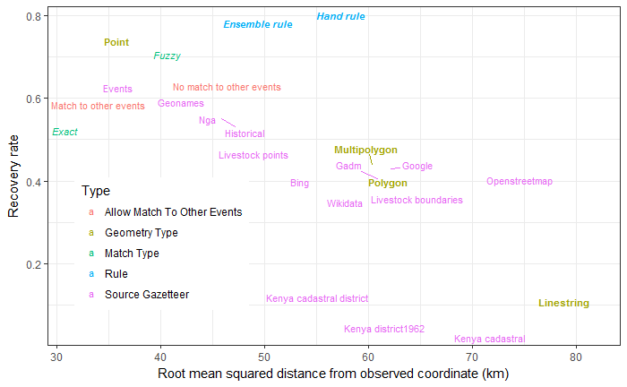

```r
p_load(Hmisc)
sentence_case <- function(x) capitalize(tolower(gsub("_"," ",x)))
#The first time you run this, you'll need to install these additional fonts
#install.packages("extrafont");
#library(extrafont)
#library(extrafont)
#extrafont::font_import(prompt=F )
#capabilities()
#windowsFonts()
#sort(as.vector(unlist(windowsFonts())))
fonts <- c('Times New Roman',
           'Calibri',
           'Courier New',
           "Georgia",
           "Tunga",
           "Lucida Fax")
           #'serif','Helvetica','Bookman','Palatino')
library(ggplot2)
fontfaces <- factor(c("plain","bold","italic","bold.italic","plain","plain"))
colours = c("Self Reference" = "#F8766D",
            "Geometry Type" = "#A3A500",
            "Match Type" = "#00BF7D",
            "Rule" = "#00B0F6",
            "Source Dataset"="#E76BF3",
            "Original Geo Info"="#53B400")
p_load(ggrepel, tools)
p_RecallBias <- recall_accuracy %>%
               filter(!label %in% "tgn") %>% #exclude TGN for being an outlier
               mutate(
                      label=sentence_case(label)
                      ) %>%
       ggplot(
       aes(x=distance_rmse,
           y=source_dataset_count / 10469,
             color=Type,
             label=label,
             family = fonts[as.numeric(as.factor(Type))],
             fontface= fontfaces[as.numeric(as.factor(Type))]
             )
)  +
  geom_text_repel(size=3) +
  theme_bw() +
  xlab(sentence_case("Root Mean Squared Distance from Observed Coordinate (km)")) +
  ylab(sentence_case("Recovery Rate")) +
  theme(
    legend.position = c(0.2, 0.3), # c(0,0) bottom left, c(1,1) top-right.
  )
p_RecallBias
 #+ coord_cartesian(y="log")
ggsave(
  filename = glue(dir_figures, "RecallBias.pdf"),
  plot = p_RecallBias, width = 9, height = 6,
    device = cairo_pdf #have to use cairo to correctly embed the fonts
)
```

# Interpretation

The hand rules and supervised ensemble represent a compromsie between high recovery rate and best case accuracy of each individual decision.